# Lineup Analysis

# Data

```r
lineup_model_data <- read_csv("lineup-model-data.csv") |>
  mutate(conf_level = factor(conf_level, levels = c("Very Certain", "Certain", "Neutral", "Uncertain", "Very Uncertain"))) |>
  mutate(conf_level_num = as.numeric(conf_level))
```

```r
lineup_model_data |>
  select(participant_id, age, gender, academic_study, dataset_id, curvature, scale, correct, response_no, binary_response, conf_level, choice_reason) |>
  head() |>
  knitr::kable()
```

| participant_id | age | gender | academic_study | dataset_id | curvature | scale | correct | response_no | binary_response | conf_level | choice_reason |
| --- | --- | --- | --- | --- | --- | --- | --- | --- | --- | --- | --- |
| 9b8fd4dc37a339758877573fedde8546 | 19-25 | Female | High School or Less | b8efad9285426a191f979b32a5094198 | t-H_n-E | log | 9 | 14 | 0 | Certain | Different range |
| 9b8fd4dc37a339758877573fedde8546 | 19-25 | Female | High School or Less | 909f6bb4a0bbb8708bcc2d96c0b7052f | t-E_n-H | linear | 17 | 17 | 1 | Very Certain | Different slope |
| 9b8fd4dc37a339758877573fedde8546 | 19-25 | Female | High School or Less | 70eebf16937fb9e77a3b806afe9aa528 | t-M_n-H | log | 13 | 1316 | 1 | Very Certain | Different shape |
| 9b8fd4dc37a339758877573fedde8546 | 19-25 | Female | High School or Less | 914e02881a7432dc34831c5dff0477e0 | t-H_n-M | log | 12 | 3 | 0 | Certain | Clustering, Different range |
| 9b8fd4dc37a339758877573fedde8546 | 19-25 | Female | High School or Less | 8105c77bcc5d38d9b4e742f1b76de5fc | t-E_n-H | linear | 15 | 15 | 1 | Very Certain | Different range, Different slope |
| 9b8fd4dc37a339758877573fedde8546 | 19-25 | Female | High School or Less | 076f2d6385d635ea49402478f7e44cab | t-E_n-M | linear | 14 | 9 | 0 | Uncertain | Different range |

# Visual of Observed Results

- There are 311 participants and 3958 lineups complete.
- Participants correctly identified the target panel in 47% of the 1981 lineup evaulations made on the linear scale and 65.3% of the 1977 lineup evaluations made on the log scale.

```r
knitr::include_graphics("prop-concept.png")
```

[output not shown]

```r
lineup_model_data <- read_csv("lineup-model-data.csv") |>
  mutate(conf_level = factor(conf_level, levels = c("Very Certain", "Certain", "Neutral", "Uncertain", "Very Uncertain"))) |>
  mutate(conf_level_num = as.numeric(conf_level))
```

```r
simData <- read.csv("../data/difficulty-comparison-data.csv")

tE_nM <- simData  |>
  mutate(Target = "High",
         Null = "Medium") |>
  filter(curvature %in% c("E", "M")) |>
  mutate(curvature = factor(curvature, levels = c("E", "M", "H"))) |>
  ggplot(aes(x = x, y = y, color = curvature, linetype = curvature)) +
  geom_line(linewidth = 1) +
  theme_test() +
  theme(aspect.ratio = 1) +
  theme(axis.text = element_blank(),
        axis.title = element_blank(),
        legend.position = "none") +
  scale_x_continuous(limits = c(0,20)) +
  scale_color_manual(values = c("green3", "black")) +
  scale_linetype_manual(values = c("solid", "dashed"))

tE_nH <- simData  |>
  mutate(Target = "High",
         Null = "Low") |>
  filter(curvature %in% c("E", "H")) |>
  mutate(curvature = factor(curvature, levels = c("E", "M", "H"))) |>
  ggplot(aes(x = x, y = y, color = curvature, linetype = curvature)) +
  geom_line(linewidth = 1) +
  theme_test() +
  theme(aspect.ratio = 1) +
  theme(axis.text = element_blank(),
        axis.title = element_blank(),
        legend.position = "none") +
  scale_x_continuous(limits = c(0,20)) +
  scale_color_manual(values = c("green3", "black")) +
  scale_linetype_manual(values = c("solid", "dashed"))

tM_nE <- simData  |>
  mutate(Target = "Medium",
         Null = "High") |>
  filter(curvature %in% c("E", "M")) |>
  mutate(curvature = factor(curvature, levels = c("E", "M", "H"))) |>
  ggplot(aes(x = x, y = y, color = curvature, linetype = curvature)) +
  geom_line(linewidth = 1) +
  theme_test() +
  theme(aspect.ratio = 1) +
  theme(axis.text = element_blank(),
        axis.title = element_blank(),
        legend.position = "none") +
  scale_x_continuous(limits = c(0,20)) +
  scale_color_manual(values = c("black", "green3")) +
  scale_linetype_manual(values = c("dashed", "solid"))

tM_nH <- simData  |>
  mutate(Target = "Medium",
         Null = "Low") |>
  filter(curvature %in% c("H", "M")) |>
  mutate(curvature = factor(curvature, levels = c("E", "M", "H"))) |>
  ggplot(aes(x = x, y = y, color = curvature, linetype = curvature)) +
  geom_line(linewidth = 1) +
  theme_test() +
  theme(aspect.ratio = 1) +
  theme(axis.text = element_blank(),
        axis.title = element_blank(),
        legend.position = "none") +
  scale_x_continuous(limits = c(0,20)) +
  scale_color_manual(values = c("green3", "black")) +
  scale_linetype_manual(values = c("solid", "dashed"))

tH_nE <- simData  |>
  mutate(Target = "Low",
         Null = "High") |>
  filter(curvature %in% c("E", "H")) |>
  mutate(curvature = factor(curvature, levels = c("E", "M", "H"))) |>
  ggplot(aes(x = x, y = y, color = curvature, linetype = curvature)) +
  geom_line(linewidth = 1) +
  theme_test() +
  theme(aspect.ratio = 1) +
  theme(axis.text = element_blank(),
        axis.title = element_blank(),
        legend.position = "none") +
  scale_x_continuous(limits = c(0,20)) +
  scale_color_manual(values = c("black", "green3")) +
  scale_linetype_manual(values = c("dashed", "solid"))

tH_nM <- simData  |>
  mutate(Target = "Low",
         Null = "Medium") |>
  filter(curvature %in% c("H", "M")) |>
  mutate(curvature = factor(curvature, levels = c("E", "M", "H"))) |>
  ggplot(aes(x = x, y = y, color = curvature, linetype = curvature)) +
  geom_line(linewidth = 1) +
  theme_test() +
  theme(aspect.ratio = 1) +
  theme(axis.text = element_blank(),
        axis.title = element_blank(),
        legend.position = "none") +
  scale_x_continuous(limits = c(0,20)) +
  scale_color_manual(values = c("black", "green3")) +
  scale_linetype_manual(values = c("dashed", "solid"))

# linear scale

tE_nH_linear <- tE_nH +
  scale_y_continuous(limits = c(10,100))

tE_nM_linear <- tE_nM +
  scale_y_continuous(limits = c(10,100))

tM_nH_linear <- tM_nH +
  scale_y_continuous(limits = c(10,100))

tM_nE_linear <- tM_nE +
  scale_y_continuous(limits = c(10,100))

tH_nM_linear <- tH_nM +
  scale_y_continuous(limits = c(10,100))

tH_nE_linear <- tH_nE +
  scale_y_continuous(limits = c(10,100))

# log scale

library(scales)

tE_nH_log <- tE_nH +
  scale_y_continuous(limits = c(10,100), trans = "log10")

tE_nM_log <- tE_nM +
  scale_y_continuous(limits = c(10,100), trans = "log10")

tM_nH_log <- tM_nH +
  scale_y_continuous(limits = c(10,100), trans = "log10")

tM_nE_log <- tM_nE +
  scale_y_continuous(limits = c(10,100), trans = "log10")

tH_nM_log <- tH_nM +
  scale_y_continuous(limits = c(10,100), trans = "log10")

tH_nE_log <- tH_nE +
  scale_y_continuous(limits = c(10,100), trans = "log10")
```

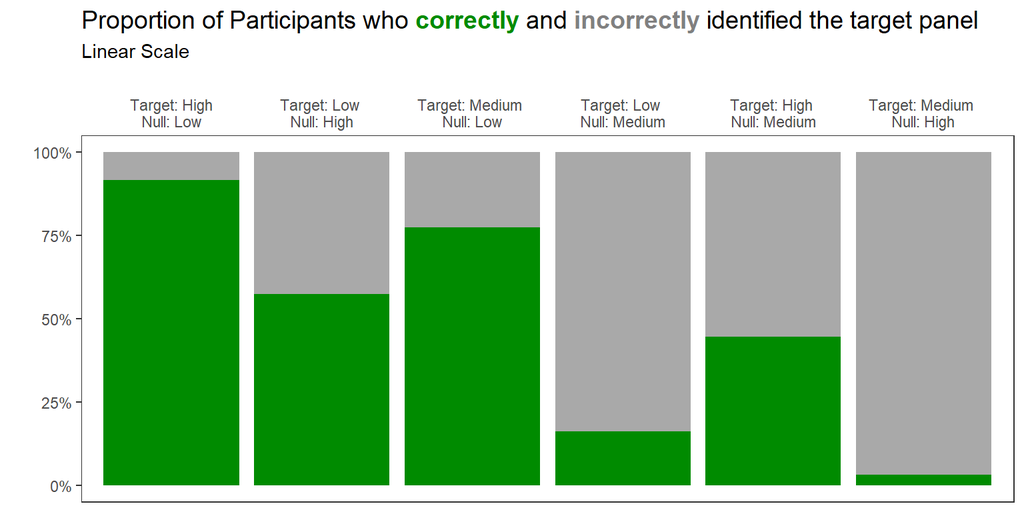

```r
scale_level <- c("linear" = "Linear Scale",
                 "log" = "Log Scale")

curvature_order <- c("t-E_n-H",
                     "t-H_n-E",
                     "t-M_n-H",
                     "t-H_n-M",
                     "t-E_n-M",
                     "t-M_n-E"
                     )

accuracy_plot_linear <- lineup_model_data |>
  filter(scale == "linear") |>
  mutate(target = factor(target, levels = c("H", "M", "E")),
         null = factor(null, levels = c("H", "M", "E")),
         curvature = factor(curvature, levels = curvature_order)
         ) |>
  ggplot(aes(x = curvature,
             fill = as.factor(binary_response))) +
  geom_bar(stat = "count",
           position = "fill") +
  # facet_wrap(~scale,
  #            ncol = 1,
  #            labeller = labeller(scale = scale_level)
  #            ) +
  scale_fill_manual(values = c("darkgray", "#008b00"), label = c("Incorrect", "Correct")) +
  scale_y_continuous(label = scales::percent) +
  scale_x_discrete(labels = c("Target: High\nNull: Low",
                              "Target: Low \nNull: High",
                              "Target: Medium \nNull: Low",
                              "Target: Low \nNull: Medium",
                              "Target: High \nNull: Medium",
                              "Target: Medium \nNull: High"),
                   position = "top") +
  labs(y = "",
       x = "",
       fill = "Target Panel \nIdentification",
       subtitle = "Linear Scale",
       title = str_c("Proportion of Participants who ", "<span style = 'color:#008b00'>**correctly**</span>", " and ",
       "<span style = 'color:#808080'>**incorrectly**</span>", " identified the target panel")) +
  theme_test() +
  theme(axis.ticks.x = element_blank(),
        plot.title = ggtext::element_markdown(size = 14),
        legend.position = "none")

accuracy_plot_linear
```

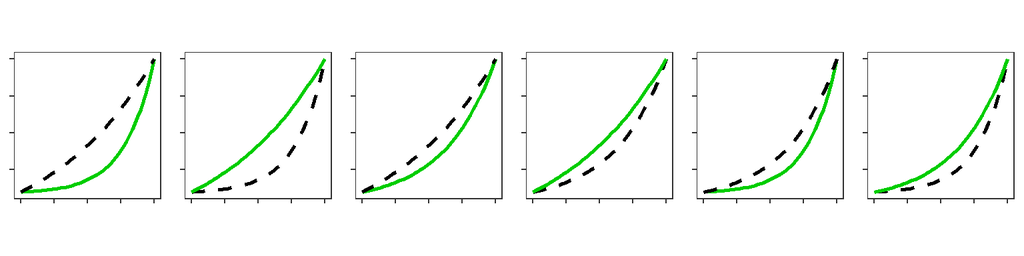

```r
# output plots with gridExtra
grid.arrange(
  tE_nH_linear,
  tH_nE_linear,
  tM_nH_linear,
  tH_nM_linear,
  tE_nM_linear,
  tM_nE_linear,
  ncol = 6
)
```

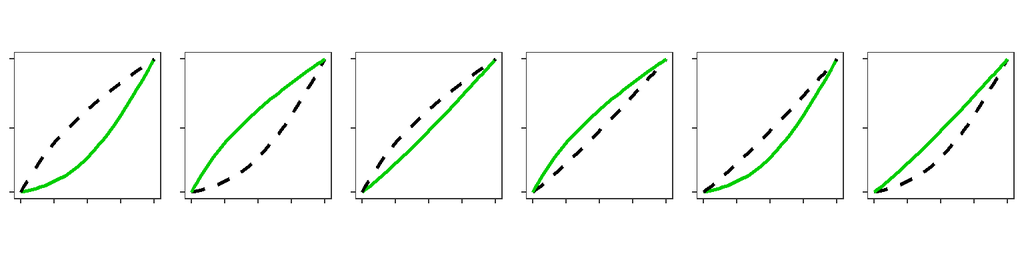

```r
grid.arrange(
  tE_nH_log,
  tH_nE_log,
  tM_nH_log,
  tH_nM_log,
  tE_nM_log,
  tM_nE_log,
  ncol = 6
)
```

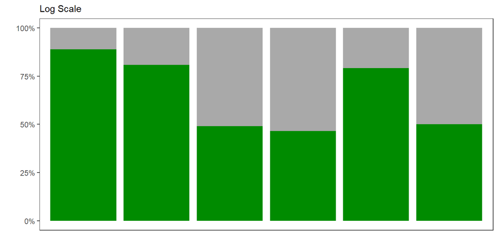

```r
accuracy_plot_log <- lineup_model_data |>
  filter(scale == "log") |>
  mutate(target = factor(target, levels = c("H", "M", "E")),
         null = factor(null, levels = c("H", "M", "E")),
         curvature = factor(curvature, levels = curvature_order)
         ) |>
  ggplot(aes(x = curvature,
             fill = as.factor(binary_response))) +
  geom_bar(stat = "count",
           position = "fill") +
  # facet_wrap(~scale,
  #            ncol = 1,
  #            labeller = labeller(scale = scale_level)
  #            ) +
  scale_fill_manual(values = c("darkgray", "#008b00"), label = c("Incorrect", "Correct")) +
  scale_y_continuous(label = scales::percent) +
  scale_x_discrete(labels = c("Target: High\nNull: Low",
                              "Target: Low \nNull: High",
                              "Target: Medium \nNull: Low",
                              "Target: Low \nNull: Medium",
                              "Target: High \nNull: Medium",
                              "Target: Medium \nNull: High")) +
  labs(y = "",
       x = "",
       fill = "Target Panel \nIdentification",
       subtitle = "Log Scale") +
  theme_test() +
  theme(axis.ticks.x = element_blank(),
        axis.text.x = element_blank(),
        legend.position = "none")

accuracy_plot_log
```

# Analysis

Target plot identification was analyzed using the `glmer` function in the `lme4` R package. Estimates and odds ratio comparisons between the log and linear scales were calculated using the `emmeans` R package. Each lineup plot evaluated was assigned a value based on the participant response (correct = 1, not correct = 0). Define $Y_{ijkl}$ to be the event that participant $l = 1,...,N_{participant}$ correctly identifies the target plot for data set $k = 1,2$ with curvature combination $j = 1,2,3,4,5,6$ plotted on scale $i = 1,2$. The binary response was analyzed using a generalized linear mixed model following a binomial distribution with a logit link function with a row-column blocking design accounting for the variation due to participant and data set respectively as
$$\begin{equation}
\text{logit }P(Y_{ijk}) = \eta + \delta_i + \gamma_j + \delta \gamma_{ij} + s_l + d_k
\end{equation}$$
where

- $\eta$ is the baseline average probability of selecting the target plot
- $\delta_i$ is the effect of scale $i = 1,2$
- $\gamma_j$ is the effect of curvature combination $j = 1,2,3,4,5,6$
- $\delta\gamma_{ij}$ is the two-way interaction between the $i^{th}$ scale and $j^{th}$ curvature combination
- $s_l \sim N(0,\sigma^2_\text{participant})$is the random effect for participant characteristics
- $d_k \sim N(0,\sigma^2_{\text{data}})$ is the random effect for data specific characteristics.

We assume that random effects for data set and participant are independent.

```r
glmm_mod <- glmer(binary_response ~ curvature*scale +
                            (1 | participant_id) +
                            (1 | dataset_id),
                  data = lineup_model_data,
                  family = binomial(link = "logit"))

lineup_anova <- car::Anova(glmm_mod) |>
  broom::tidy()
# summary(glmm_mod)

lineup_anova |>
  knitr::kable(digits = 3, caption = "Lineups GLMM ANOVA")
```

Lineups GLMM ANOVA

| term | statistic | df | p.value |
| --- | --- | --- | --- |
| curvature | 32.152 | 5 | 0 |
| scale | 96.685 | 1 | 0 |
| curvature:scale | 294.236 | 5 | 0 |

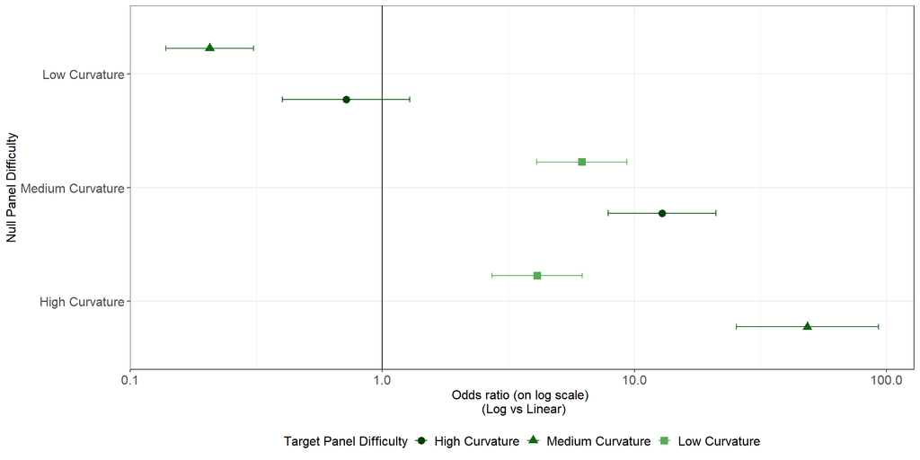

```r
lineups_or <- emmeans(glmm_mod, ~ scale | curvature, type = "response") |>
  pairs(reverse = T, infer = c(T,T)) |>
  as_tibble()

# write.csv(lineups_or, here("analyses/01-lineups/results/lineups-odds-ratios.csv"), row.names = F, na =)

dodge <- position_dodge(width=0.9)
lineups_or_plot <- lineups_or %>%
  separate(curvature, into = c(NA, "target", NA, "null")) %>%
  mutate(null = factor(null, levels = c("E", "M", "H"), labels = c("High Curvature", "Medium Curvature", "Low Curvature")),
         target = factor(target, levels = c("E", "M", "H"), labels = c("High Curvature", "Medium Curvature", "Low Curvature"))) %>%
  ggplot(aes(x = odds.ratio, y = null, color = target, shape = target)) +
  geom_point(position = dodge, size = 3) +
  geom_errorbar(aes(xmin = asymp.LCL, xmax = asymp.UCL), position = dodge, width = .1) +
  geom_vline(xintercept = 1) +
  theme_bw()  +
  theme(axis.title = element_text(size = 12),
        axis.text = element_text(size = 12),
        legend.title = element_text(size = 12),
        legend.text  = element_text(size = 12),
        legend.key.size = unit(1, "line"),
        legend.position = "bottom"
  ) +
  scale_y_discrete("Null Panel Difficulty", position = "left") +
  scale_x_continuous("Odds ratio (on log scale) \n (Log vs Linear)", trans = "log10", labels = scales::comma) +
  scale_color_manual("Target Panel Difficulty", values = c("#004400", "#116611", "#55aa55")) +
  scale_shape_discrete("Target Panel Difficulty")

lineups_or_plot
```

# Confidence Level Analysis

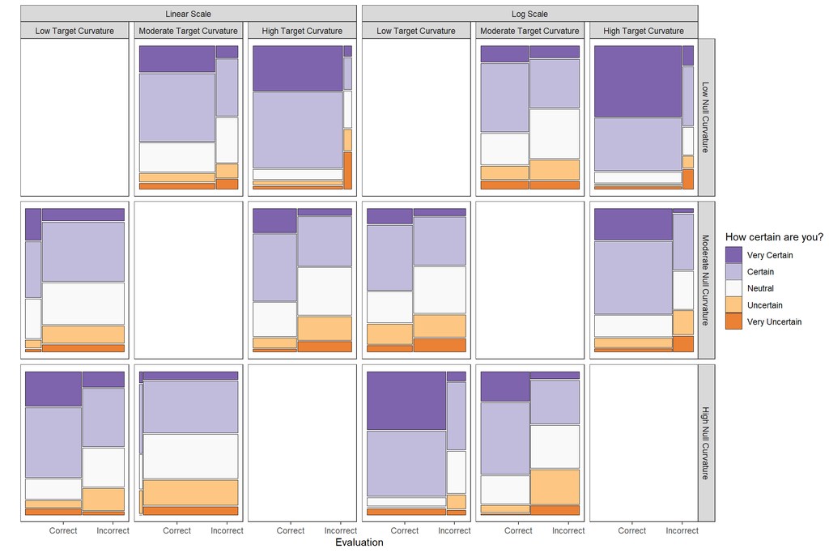

```r
# labellers for plotting
target_level <- c(
  "H" = "Low Target Curvature",
  "M" = "Moderate Target Curvature",
  "E" = "High Target Curvature"
)

null_level <- c(
  "H" = "Low Null Curvature",
  "M" = "Moderate Null Curvature",
  "E" = "High Null Curvature"
)

scale_level <- c("linear" = "Linear Scale",
                 "log" = "Log Scale")

lineup_model_data |>
  mutate(target = factor(target, levels = c("H", "M", "E")),
         null = factor(null, levels = c("H", "M", "E")),
         conf_level = factor(conf_level, levels = c("Very Uncertain", "Uncertain", "Neutral", "Certain", "Very Certain")),
         binary_response = factor(binary_response, levels = c(1,0), labels = c("Correct", "Incorrect"))
         ) |>
  ggplot() +
  geom_mosaic(aes(x = product(binary_response),
             fill = conf_level),
             show.legend = T,
             color = "black") +
  facet_nested(null ~ scale + target,
               # labeller = label_both
             labeller = labeller(scale = scale_level,
                                 null = null_level,
                                 target = target_level)
             ) +
  scale_fill_brewer(palette = "PuOr",
                    guide = guide_legend(reverse = TRUE)) +
  labs(y = "",
       x = "Evaluation",
       fill = "How certain are you?") +
  theme_test() +
  theme(axis.text.y = element_blank(),
        axis.ticks.y = element_blank())
```

```r
confidence_data <- lineup_model_data |>
  select(participant_id, curvature, target, null, scale, binary_response, conf_level, conf_level_num) |>
  mutate(binary_response = factor(binary_response, levels = c(1,0), labels = c("Correct", "Incorrect"))) |>
  mutate(conf_level_num2 = 6 - conf_level_num)

# linear model
library(lme4)
confidence_model <- lmer(conf_level_num2 ~ curvature*scale*binary_response + (1|participant_id),
                       data = confidence_data)
library(lmerTest)
anova(confidence_model)
```

```
Analysis of Variance Table
                                npar Sum Sq Mean Sq  F value
curvature                          5 342.56  68.513 113.4393
scale                              1  16.54  16.537  27.3817
binary_response                    1 189.93 189.927 314.4698
curvature:scale                    5  44.48   8.895  14.7279
curvature:binary_response          5  16.88   3.377   5.5912
scale:binary_response              1   0.92   0.923   1.5276
curvature:scale:binary_response    5   5.67   1.134   1.8775
```

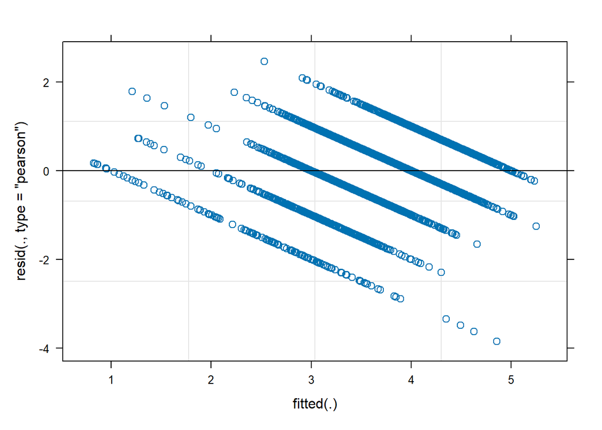

```r
plot(confidence_model)
```

```r
library(emmeans)
emmeans(confidence_model, specs =~ binary_response|curvature) |> pairs()
```

```
curvature = t-E_n-H:
 contrast            estimate     SE  df z.ratio p.value
 Correct - Incorrect    0.942 0.1117 Inf   8.427  <.0001

curvature = t-E_n-M:
 contrast            estimate     SE  df z.ratio p.value
 Correct - Incorrect    0.631 0.0709 Inf   8.891  <.0001

curvature = t-H_n-E:
 contrast            estimate     SE  df z.ratio p.value
 Correct - Incorrect    0.649 0.0744 Inf   8.727  <.0001

curvature = t-H_n-M:
 contrast            estimate     SE  df z.ratio p.value
 Correct - Incorrect    0.360 0.0747 Inf   4.814  <.0001

curvature = t-M_n-E:
 contrast            estimate     SE  df z.ratio p.value
 Correct - Incorrect    0.423 0.1264 Inf   3.347  0.0008

curvature = t-M_n-H:
 contrast            estimate     SE  df z.ratio p.value
 Correct - Incorrect    0.391 0.0717 Inf   5.459  <.0001

Results are averaged over the levels of: scale
Degrees-of-freedom method: asymptotic
```

```r
emmeans(confidence_model, specs =~ scale|curvature) |> pairs()
```

```
curvature = t-E_n-H:
 contrast     estimate     SE  df z.ratio p.value
 linear - log   -0.326 0.1084 Inf  -3.006  0.0026

curvature = t-E_n-M:
 contrast     estimate     SE  df z.ratio p.value
 linear - log   -0.110 0.0701 Inf  -1.572  0.1158

curvature = t-H_n-E:
 contrast     estimate     SE  df z.ratio p.value
 linear - log   -0.198 0.0731 Inf  -2.703  0.0069

curvature = t-H_n-M:
 contrast     estimate     SE  df z.ratio p.value
 linear - log    0.289 0.0736 Inf   3.926  0.0001

curvature = t-M_n-E:
 contrast     estimate     SE  df z.ratio p.value
 linear - log   -0.224 0.1256 Inf  -1.784  0.0745

curvature = t-M_n-H:
 contrast     estimate     SE  df z.ratio p.value
 linear - log    0.146 0.0709 Inf   2.054  0.0400

Results are averaged over the levels of: binary_response
Degrees-of-freedom method: asymptotic
```

```r
emmeans(confidence_model, specs =~ binary_response) |> pairs()
```

```
 contrast            estimate     SE  df z.ratio p.value
 Correct - Incorrect    0.566 0.0386 Inf  14.648  <.0001

Results are averaged over the levels of: curvature, scale
Degrees-of-freedom method: asymptotic
```

```r
emmeans(confidence_model, specs =~ scale) |> pairs()
```

```
 contrast     estimate     SE  df z.ratio p.value
 linear - log  -0.0705 0.0366 Inf  -1.925  0.0543

Results are averaged over the levels of: curvature, binary_response
Degrees-of-freedom method: asymptotic
```

# Rorschach lineups

```r
lineup_rorschach_data <- read_csv("lineup-rorschach-data.csv") |>
  mutate(conf_level = factor(conf_level, levels = c("Very Certain", "Certain", "Neutral", "Uncertain", "Very Uncertain"))) |>
  mutate(conf_level_num = as.numeric(conf_level))
lineup_rorschach_data
```

```
# A tibble: 431 × 19
   evaluation_id            participant_id n_lineups age   gender academic_study
   <chr>                    <chr>              <dbl> <chr> <chr>  <chr>
 1 d61a69c248335d463dccffa… 68c1934bf5e5e…         1 19-25 Male   Some Undergra…
 2 d61a69c248335d463dccffa… 68c1934bf5e5e…         1 19-25 Male   Some Undergra…
 3 84c392f926226c9f5b7c1b9… 03e791a1817ef…         1 56-60 Female Graduate Degr…
 4 13e72c242214915e3e43973… a24b5e2ed09da…         2 19-25 Male   Prefer not to…
 5 09910b4ccd4c7959638a465… a24b5e2ed09da…         2 19-25 Male   Prefer not to…
 6 544ebe80b5b86544b13278a… e12649087db38…         3 31-35 Male   High School o…
 7 342425ad988c128c7d6333a… e12649087db38…         3 31-35 Male   High School o…
 8 c22ad2fc4945d4bbee3f628… e12649087db38…         3 31-35 Male   High School o…
 9 c22ad2fc4945d4bbee3f628… e12649087db38…         3 31-35 Male   High School o…
10 feac43b711f3e2019e805e9… e6f6b84728ecf…         1 26-30 Female Undergraduate…
# ℹ 421 more rows
# ℹ 13 more variables: computer_mouse <chr>, recruitment <chr>,
#   dataset_id <chr>, set <dbl>, curvature <chr>, target <chr>, null <chr>,
#   scale <chr>, correct <dbl>, response_no <dbl>, conf_level <fct>,
#   choice_reason <chr>, conf_level_num <dbl>
```

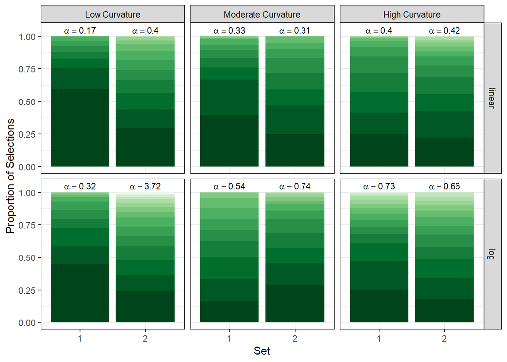

```r
# Calculate alphas
# install.packages("devtools")
# devtools::install_github("heike/vinference")
library(vinference)
npanels = 20

calcAlpha <- function(data, m0 = 20) {

  K = nrow(data)
  c = m0/K
  zc = data |>
    select(response_no) |>
    count(response_no) |>
    arrange(-n) |>
    filter(n >= c) |>
    nrow()

  results <- estimate_alpha_numeric(Zc = zc,
                         c = c,
                         m0 = m0,
                         K  = K
                         )

  return(results$alpha)
}

alpha_values <- lineup_rorschach_data |>
  nest(-target, -set, -scale) |>
  arrange(target, set, scale) |>
  mutate(alpha = map(.x = data,
                     .f = calcAlpha)
         ) |>
  unnest(alpha) |>
  mutate(target = fct_relevel(target,
                              c("H", "M", "E"))) |>
  select(set, target, scale, alpha)

# unique(lineup_rorschach_data$dataset_id) |> length()
target_level <- c(
  "H" = "Low Curvature",
  "M" = "Moderate Curvature",
  "E" = "High Curvature"
)

library(RColorBrewer)
nb.cols <- 16
mycolors <- colorRampPalette(brewer.pal(16, "Greens"))(nb.cols)

freqNum = function(data){
  data2 <- data |>
    mutate(freq_order = 1:n())
  return(data2)
}

rorschach_summary <- lineup_rorschach_data |>
  mutate(target = fct_relevel(target,
                              c("H", "M", "E"))) |>
  group_by(evaluation_id, dataset_id, set, target, scale) |>
  mutate(weight = 1/n()) |>
  ungroup() |>
  group_by(dataset_id, set, target, scale) |>
  count(response_no, wt = weight) |>
  arrange(dataset_id, set, target, scale, -n) |>
  nest(data = c(response_no, n)) |>
  mutate(data2 = map(data, freqNum)) |>
  unnest(data2) |>
  select(-data)

rorschach_summary |>
  ggplot(aes(x = as.factor(set),
             y = n
             )
         ) +
  geom_bar(stat = "identity",
           position = "fill",
           show.legend = F,
           aes(fill = fct_rev(as.factor(freq_order)))
           ) +
  geom_text(data = alpha_values,
            aes(label = paste0("alpha ==", round(alpha, 2)),
                y = 1.05
                ),
            size = 3,
            parse = TRUE
            ) +
  facet_grid(scale ~ target,
             scales = "free_x",
             labeller = labeller(target = target_level)
             ) +
  theme_bw() +
  scale_fill_manual(values = mycolors) +
  labs(x = "Set",
       y = "Proportion of Selections",
       fill = "Identification")
```